# Beers&Breweries

Dawn Bowerman

10/7/2020

#Beers and Breweries RMD:Exploratory Data Analysis of U.S. Beers and Breweries for Budweiser

# Question Number 1: How many breweries are present in each state?

## This code gets count by state and gives the summary statistics.

###The Median breweries per state is 7.00, the Mean is 10.94. The least amount per state is 1 and the most is 47 (Colorado)

```r
library(GGally)
library(tidyverse)
```

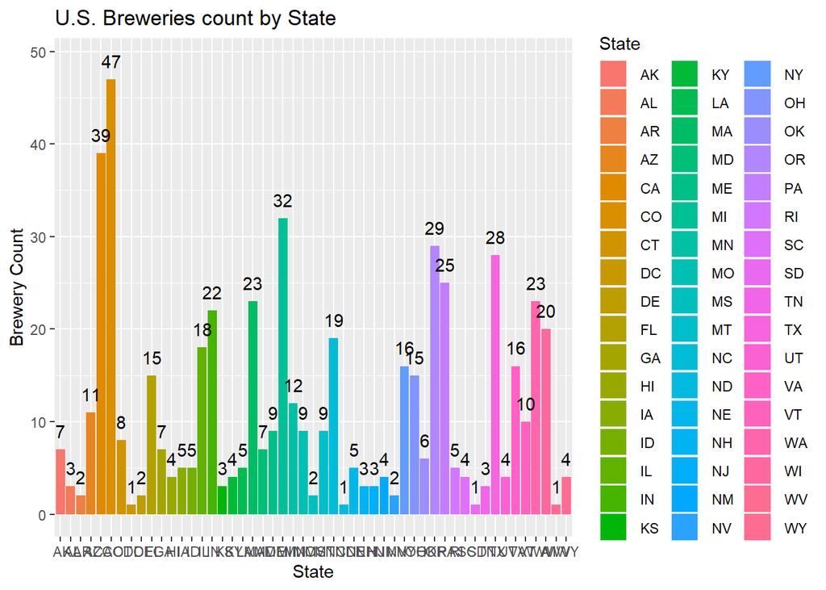

```r
Breweries <- read.csv("H:/Schools/SMU/DoingDataScienceHomework/UnitOne/Unit One/Unit 8 and 9 Case Study 1/Breweries.csv")
Beers <- read.csv("H:/Schools/SMU/DoingDataScienceHomework/UnitOne/Unit One/Unit 8 and 9 Case Study 1/Beers.csv")


BrewCount <- Breweries %>% group_by(State)
view(BrewCount)

totalBrewCount = count(Breweries, State)
view(totalBrewCount)


Breweries %>% ggplot(aes(x = State, fill = State)) + geom_bar() + geom_text(aes(State, totalBrewCount$n+2, label = totalBrewCount$n, fill = NULL), data = totalBrewCount) + ggtitle("U.S. Breweries count by State") + ylab("Brewery Count")
```

```r
summary(totalBrewCount)
```

```
##     State                 n
##  Length:51          Min.   : 1.00
##  Class :character   1st Qu.: 3.50
##  Mode  :character   Median : 7.00
##                     Mean   :10.94
##                     3rd Qu.:16.00
##                     Max.   :47.00
```

# Question # 2: Merge beer data with the breweries data. Print the first 6 observations and the last six observations to check the merged file.

## This code merges the two dataframes and prints the first and last 6

```r
mergeBeerBrew <- merge(Breweries,Beers, by.x = "Brew_ID", by.y = "Brewery_id")

head(mergeBeerBrew)
```

```
##   Brew_ID             Name.x        City State        Name.y Beer_ID   ABV IBU
## 1       1 NorthGate Brewing  Minneapolis    MN       Pumpion    2689 0.060  38
## 2       1 NorthGate Brewing  Minneapolis    MN    Stronghold    2688 0.060  25
## 3       1 NorthGate Brewing  Minneapolis    MN   Parapet ESB    2687 0.056  47
## 4       1 NorthGate Brewing  Minneapolis    MN  Get Together    2692 0.045  50
## 5       1 NorthGate Brewing  Minneapolis    MN Maggie's Leap    2691 0.049  26
## 6       1 NorthGate Brewing  Minneapolis    MN    Wall's End    2690 0.048  19
##                                 Style Ounces
## 1                         Pumpkin Ale     16
## 2                     American Porter     16
## 3 Extra Special / Strong Bitter (ESB)     16
## 4                        American IPA     16
## 5                  Milk / Sweet Stout     16
## 6                   English Brown Ale     16
```

```r
tail(mergeBeerBrew)
```

```
##      Brew_ID                        Name.x          City State
## 2405     556         Ukiah Brewing Company         Ukiah    CA
## 2406     557       Butternuts Beer and Ale Garrattsville    NY
## 2407     557       Butternuts Beer and Ale Garrattsville    NY
## 2408     557       Butternuts Beer and Ale Garrattsville    NY
## 2409     557       Butternuts Beer and Ale Garrattsville    NY
## 2410     558 Sleeping Lady Brewing Company     Anchorage    AK
##                         Name.y Beer_ID   ABV IBU                   Style Ounces
## 2405             Pilsner Ukiah      98 0.055  NA         German Pilsener     12
## 2406         Porkslap Pale Ale      49 0.043  NA American Pale Ale (APA)     12
## 2407           Snapperhead IPA      51 0.068  NA            American IPA     12
## 2408         Moo Thunder Stout      50 0.049  NA      Milk / Sweet Stout     12
## 2409  Heinnieweisse Weissebier      52 0.049  NA              Hefeweizen     12
## 2410 Urban Wilderness Pale Ale      30 0.049  NA        English Pale Ale     12
```

# number 3: Address the missing values in each column; also see next chunk.

## This chunk shows where the missing values are in the dataframe.

### After viewing the areas where there is missing data, I have determined to delete the NAs out of some of the analysis (IBU - ALe comparison, median alcohol) where it doesn’t effect the result as much and leave in where it does (such as number of breweries.) The missing values are MCAR (Missing Completely at Random) in my determination as their missing value has nothing to do with their hypothetical value and with the values of other variables.

```r
cleanMergeBeerBrew <- !is.na(mergeBeerBrew)
view(cleanMergeBeerBrew)
```

# number3 & 4: Address the missing values in each column & Compute the median alcohol content for each state. Plot a bar chart to compare.

### The median alcohol by volume for most states is about 0.056, Utah and New Jersey are atypically low.

## This chunk filters the ABV na’s out of the dataframe and summarizes the median Alcohol by Volume by state and plots it

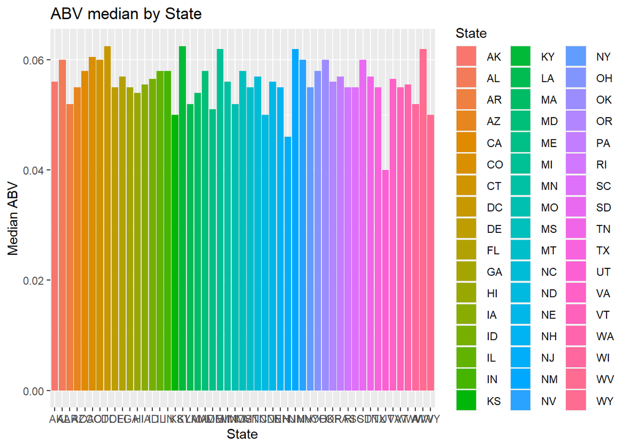

```r
mergeBeerBrew %>% filter(!is.na(ABV)) %>% group_by(State) %>% summarise(medianABV = median(ABV),count = n()) %>% ggplot(aes(x = State, y = medianABV, fill = State)) + geom_bar(stat="identity") + ggtitle("ABV median by State") + ylab("Median ABV")
```

# number3 & 4: Address the missing values in each column & Compute the international bitterness unit for each state. Plot a bar chart to compare.

##This chunk filters the IBU Na’s out of the dataframe and summarizes the median International Bitterness Units (IBU) by state and plots it

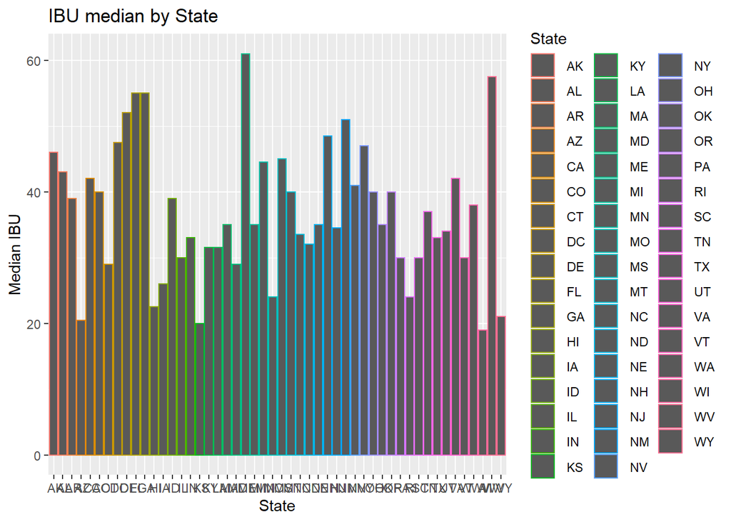

```r
 mergeBeerBrew %>% filter(!is.na(IBU)) %>% group_by(State) %>% summarize(medianIBU = median(IBU), count = n()) %>% ggplot(aes(x = State, y = medianIBU, color = State)) + geom_bar(stat="identity") + ggtitle("IBU median by State") + ylab("Median IBU")
```

# Question number 5.1; Which state has the maximum alcoholic (ABV) beer?

## The State with the beer with the highest ABV is Colorado. Kentucky and Indiana are second and third. Most breweries have a maximum ABV of 0.100.

### This chunk groups by ABV and State and plots the Alcohol by Volume (ABV) by state.

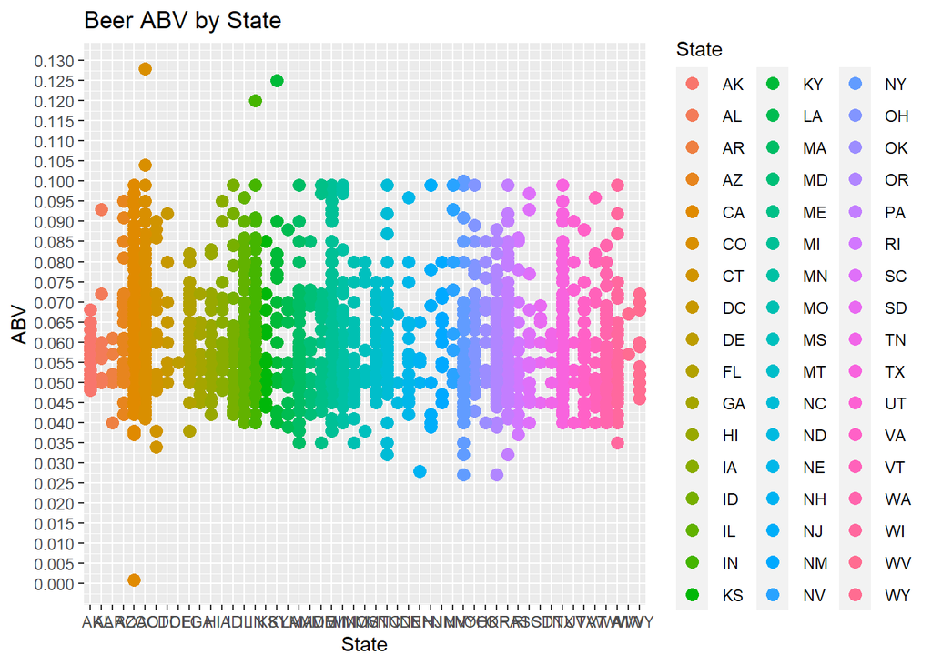

```r
by_ABVBeerBrew <- mergeBeerBrew %>% group_by(ABV, State)
view(by_ABVBeerBrew)

ggplot(by_ABVBeerBrew, aes(x=State, y=ABV, color = State)) +
  geom_point(size=3) + ggtitle("Beer ABV by State") + scale_y_continuous(breaks=seq(0, 0.150, by = 0.005))
```

# Question number 5.2; Which state has the most bitter (IBU) beer?

### This chunk groups by IBU and State and plots the International Bitterness Unit (IBV) by state

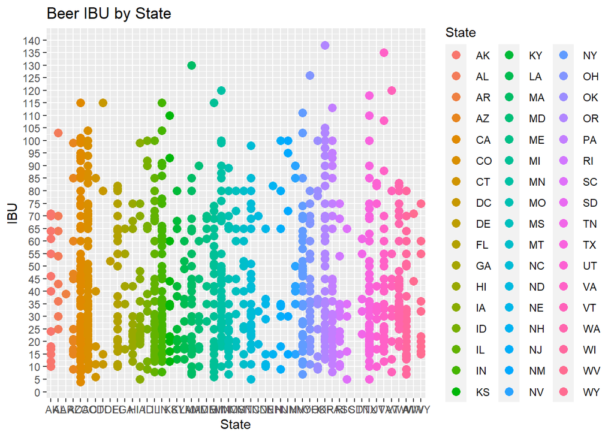

```r
by_IBUBeerBrew <- mergeBeerBrew %>% group_by(IBU, State)
view(by_ABVBeerBrew)

ggplot(by_IBUBeerBrew, aes(x=State, y=IBU, color = State)) +
  geom_point(size=3) + ggtitle("Beer IBU by State") + scale_y_continuous(breaks=seq(0, 175, by = 5))
```

# question number 6: Comment on the summary statistics and distribution of the ABV variable

## The distribution of the Alcohol by Volume variable is right-skewed starting at about 0.025 and The largest portion ends at about 0.10 and then has a few outliers after that. The median is 0.05600 and the mean is 0.05977. The Max is 0.128 ABV. There were 62 beers that did not have their ABV listed in the dataframe.

### This chunk filters the na’s of the ABV variable and plots a histogram of the ABV. Then gives a summary of the variable.

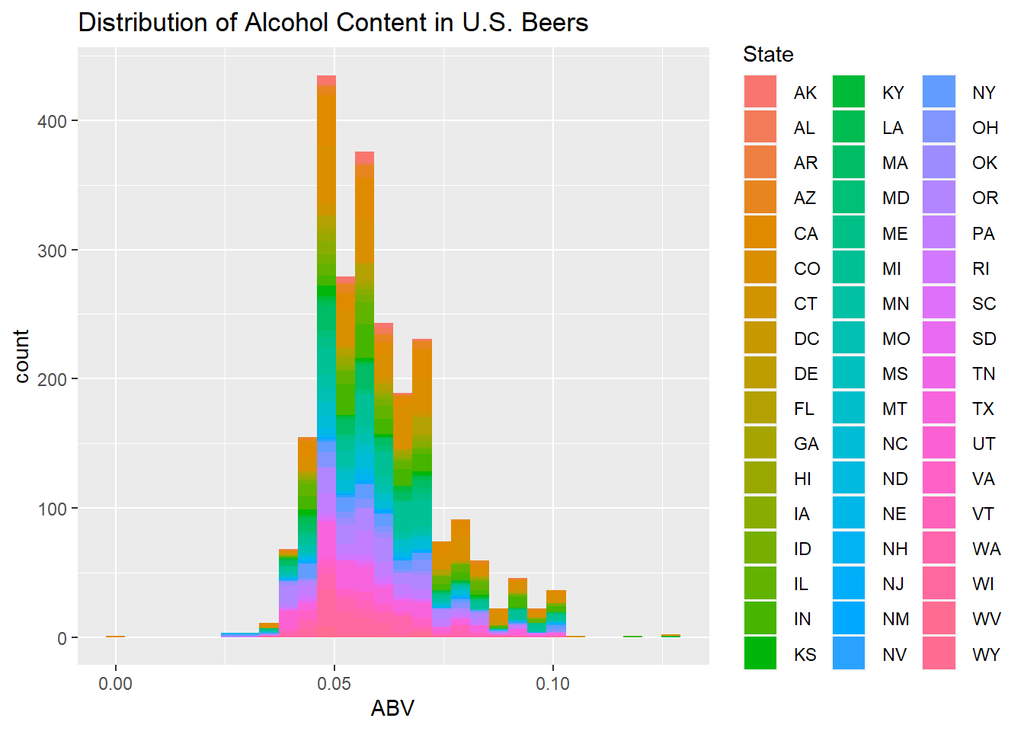

```r
mergeBeerBrew %>% filter(!is.na(ABV)) %>% group_by(ABV) %>%
ggplot(aes(x = ABV, fill = State)) +
geom_histogram() + ggtitle("Distribution of Alcohol Content in U.S. Beers")
```

```r
summary(mergeBeerBrew$ABV)
```

```
##    Min. 1st Qu.  Median    Mean 3rd Qu.    Max.    NA's
## 0.00100 0.05000 0.05600 0.05977 0.06700 0.12800      62
```

# Question 7.1; Is there an apparent relationship between the bitterness of the beer and its alcoholic content? Draw a scatter plot. Make your best judgment of a relationship and EXPLAIN your answer.

## Looking at the graph, The relationship between ABU and IBU does look linear, however there is an area at 0.05 ABV and 20-25 IBU that’s dense indicating that most beers are created with these characteristics. Notice also, that there are some high ABV beers that are not as bitter; This might be beers that don’t have as much hops in them or were created to be less bitter.

### This code plots a scatter plot of ABV by IBU and colors by State.

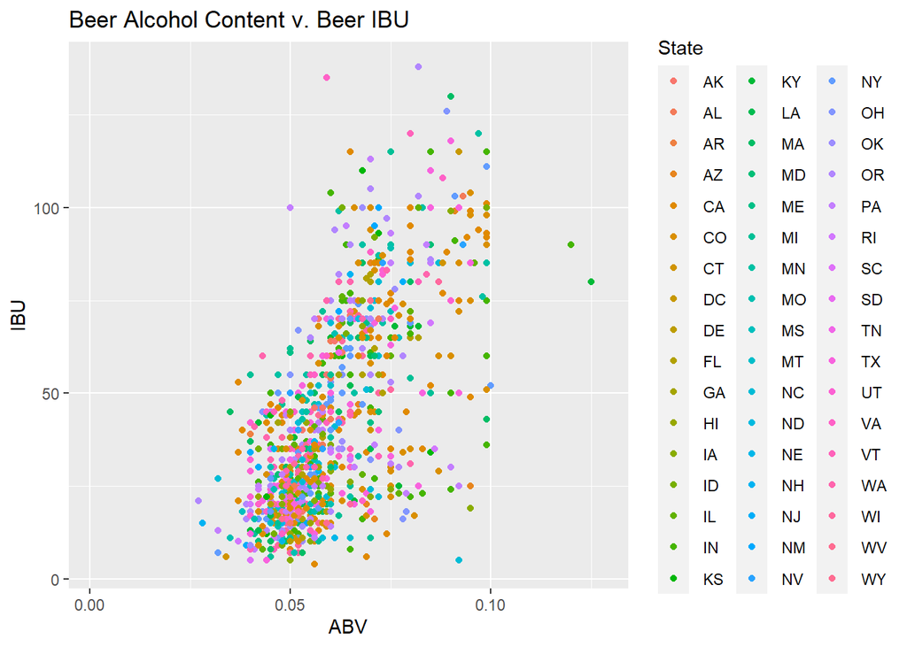

```r
mergeBeerBrew %>%
ggplot(aes(x = ABV, y = IBU, color = State)) +
geom_point() + ggtitle("Beer Alcohol Content v. Beer IBU")
```

# Question 7.2; ABV vs. IBU by State;

## If you look at each states’ plot some are very linear where others tend to split off from the main line. Each state has a unique profile. It would seem some beers are made with a high ABV and a lower bitterness profile. You can still see the dense area at 0.055 ABV and 20-25 IBU especially in the Colorado and California plots.

### This chunk does the same as the previous code but with separate graphs by state.

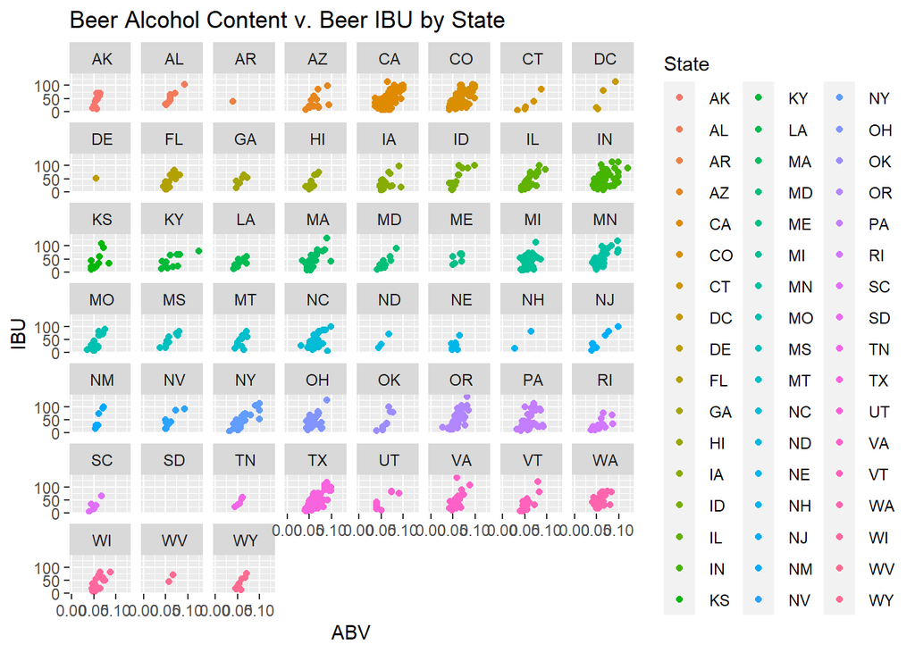

```r
ggplot(data = mergeBeerBrew) +
  geom_point(mapping = aes(x = ABV, y = IBU, color = State)) +
  facet_wrap(~State) + ggtitle("Beer Alcohol Content v. Beer IBU by State")
```

# Question 8.1; Budweiser would also like to investigate the difference with respect to IBU and ABV between IPAs (India Pale Ales) and other types of Ale (any beer with “Ale” in its name other than IPA). You decide to use KNN classification to investigate this relationship. Provide statistical evidence one way or the other.

## This chunk sets up the statistical packages and merges and filters the data again for the following code.

```r
library(class)
library(caret)
library(e1071)
#############

#merge Beer and Breweries

mergeBeerBrew <- merge(Breweries,Beers, by.x = "Brew_ID", by.y = "Brewery_id")

# filtered na's for both IBU and ABV
 filmerBeerBrw <- mergeBeerBrew %>% filter(!is.na(ABV)) %>%  filter(!is.na(IBU))
 view(filmerBeerBrw)
```

# Question 8.2; Budweiser would also like to investigate the difference with respect to IBU and ABV between IPAs (India Pale Ales) and other types of Ale (any beer with “Ale” in its name other than IPA). You decide to use KNN classification to investigate this relationship. Provide statistical evidence one way or the other.

## This code filters the Style column and creates a new column based on the type of Beer in the Style column. Getting the data ready to use in the KNN code.

```r
filmerBeerBrw %>% filter(grepl('\\bale\\b', Style, ignore.case=T)) %>%
filter(grepl('\\bale\\b', Style, ignore.case=T)) %>%
filter(grepl('\\bIPA\\b', Style, ignore.case=T))
```

```
##   Brew_ID                     Name.x                City State
## 1      54          Bent Brewstillery           Roseville    MN
## 2     108    Bonfire Brewing Company               Eagle    CO
## 3     216         Texian Brewing Co.            Richmond    TX
## 4     269 Long Trail Brewing Company Bridgewater Corners    VT
## 5     279  Berkshire Brewing Company     South Deerfield    MA
## 6     438           Brooklyn Brewery            Brooklyn    NY
## 7     438           Brooklyn Brewery            Brooklyn    NY
##                        Name.y Beer_ID   ABV IBU                        Style
## 1                        Moar    2558 0.044  44 English India Pale Ale (IPA)
## 2 Farmer Wirtz India Pale Ale    1549 0.070  94 English India Pale Ale (IPA)
## 3                      Brutus    2116 0.071  69 English India Pale Ale (IPA)
## 4              Long Trail IPA    1926 0.059  42 English India Pale Ale (IPA)
## 5             Lost Sailor IPA    1900 0.055  40 English India Pale Ale (IPA)
## 6         East India Pale Ale     566 0.068  47 English India Pale Ale (IPA)
## 7         East India Pale Ale    1279 0.068  47 English India Pale Ale (IPA)
##   Ounces
## 1     12
## 2     16
## 3     12
## 4     12
## 5     12
## 6     12
## 7     16
```

```r
Ales.beer <- cbind(filmerBeerBrw, type='Ales', stringsAsFactors=F) %>% filter(grepl('\\bale\\b', Style, ignore.case=T))

view(Ales.beer)


filmerBeerBrw %>% filter(grepl('\\bipa\\b', Style, ignore.case=T)) %>%
filter(grepl('\\bipa\\b', Style, ignore.case=T)) %>%
filter(grepl('\\bAle\\b', Style, ignore.case=T))
```

```
##   Brew_ID                     Name.x                City State
## 1      54          Bent Brewstillery           Roseville    MN
## 2     108    Bonfire Brewing Company               Eagle    CO
## 3     216         Texian Brewing Co.            Richmond    TX
## 4     269 Long Trail Brewing Company Bridgewater Corners    VT
## 5     279  Berkshire Brewing Company     South Deerfield    MA
## 6     438           Brooklyn Brewery            Brooklyn    NY
## 7     438           Brooklyn Brewery            Brooklyn    NY
##                        Name.y Beer_ID   ABV IBU                        Style
## 1                        Moar    2558 0.044  44 English India Pale Ale (IPA)
## 2 Farmer Wirtz India Pale Ale    1549 0.070  94 English India Pale Ale (IPA)
## 3                      Brutus    2116 0.071  69 English India Pale Ale (IPA)
## 4              Long Trail IPA    1926 0.059  42 English India Pale Ale (IPA)
## 5             Lost Sailor IPA    1900 0.055  40 English India Pale Ale (IPA)
## 6         East India Pale Ale     566 0.068  47 English India Pale Ale (IPA)
## 7         East India Pale Ale    1279 0.068  47 English India Pale Ale (IPA)
##   Ounces
## 1     12
## 2     16
## 3     12
## 4     12
## 5     12
## 6     12
## 7     16
```

```r
IPAs.beer <- cbind(filmerBeerBrw, type='IPAs', stringsAsFactors=F) %>% filter(grepl('\\bipa\\b', Style, ignore.case=T))

view(IPAs.beer)
```

# Question 8.3; Budweiser would also like to investigate the difference with respect to IBU and ABV between IPAs (India Pale Ales) and other types of Ale (any beer with “Ale” in its name other than IPA). You decide to use KNN classification to investigate this relationship. Provide statistical evidence one way or the other.

## This chunk combines the two previous dataframes by row & filters NA’s.

```r
AllIPAsAleBeers <- rbind(Ales.beer, IPAs.beer)

 na.meripa.aleBeerBrw <- AllIPAsAleBeers %>% filter(!is.na(ABV)) %>%  filter(!is.na(IBU))
 view(na.meripa.aleBeerBrw)
```

#Question 8.4; Budweiser would also like to investigate the difference with respect to IBU and ABV between IPAs (India Pale Ales) and other types of Ale (any beer with “Ale” in its name other than IPA). You decide to use KNN classification to investigate this relationship. Provide statistical evidence one way or the other.

```r
splitPerc = .75

iterations = 500
numks = 30

masterAcc = matrix(nrow = iterations, ncol = numks)

for(j in 1:iterations)
{
accs = data.frame(accuracy = numeric(30), k = numeric(30))
trainIndices = sample(1:dim(na.meripa.aleBeerBrw)[1],round(splitPerc * dim(na.meripa.aleBeerBrw)[1]))
train = na.meripa.aleBeerBrw[trainIndices,]
test = na.meripa.aleBeerBrw[-trainIndices,]
for(i in 1:numks)
{
  classifications = knn(train[,c(7,8)],test[,c(7,8)],train$type, prob = TRUE, k = i)
  table(classifications,test$type)
  CM = confusionMatrix(table(classifications,test$type))
  masterAcc[j,i] = CM$overall[1]
}

}

MeanAcc = colMeans(masterAcc)

plot(seq(1,numks,1),MeanAcc, type = "l")
```

[output not shown]

# Question 8.5; Budweiser would also like to investigate the difference with respect to IBU and ABV between IPAs (India Pale Ales) and other types of Ale (any beer with “Ale” in its name other than IPA). You decide to use KNN classification to investigate this relationship. Provide statistical evidence one way or the other.

```r
classifications = knn(train[,c(7,8)],test[,c(7,8)],train$type, prob = TRUE, k = 6)
```

[output not shown]

```r
table(test$type,classifications)
```

[output not shown]

```r
confusionMatrix(table(test$type,classifications))
```

[output not shown]

# Question 9; Number of Ales Vs. Number of IPAs by State.

### This code gives the number of Ales vs. the number of IPAs by State.

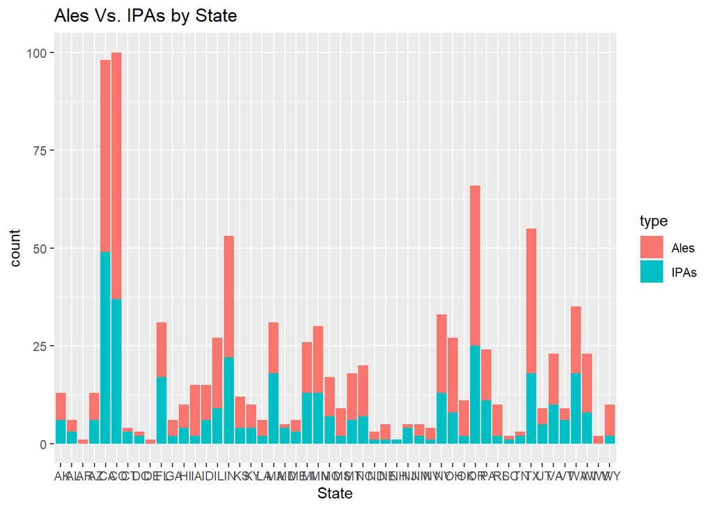

```r
  na.meripa.aleBeerBrw %>% ggplot(aes(x = State, fill = type)) + geom_bar() + ggtitle("Ales Vs. IPAs by State")
```